# ЕГЭ 2018 Вариант 14 EGE 2018 Variant 14

Использованы материалы:

The list of used links and books:

[ЕГЭ 2018. Математика. Профильный уровень. 20 вариантов тестов. Тематическая рабочая тетрадь.](https://drive.google.com/file/d/0B8CJrELbJAyodmtvbV8xcEtZXzA/view)

[SymPy Tutorials](http://nbviewer.jupyter.org/url/www.inp.nsk.su/~grozin/python/sympy.ipynb)

[LaTeX Mathematics](https://en.wikibooks.org/wiki/LaTeX/Mathematics)

[Метод рационализации неравенств (логарифмы)](http://internat.msu.ru/wp-content/uploads/2015/11/Metod-ratsionalizatsii-neravenstv-1.pdf)

```python
%%html
<style>
@import url('https://fonts.googleapis.com/css?family=Roboto&effect=3d|scuffed-steel|static|canvas-print|');
a, h1 h2, h3, h4, div.text_cell_render {font-family: 'Roboto'; text-shadow: 4px 4px 4px #aaa;}

h2, h3, div.output_prompt, div.output_area pre {color: slategray;}
h1, h4, div.input_prompt {color: steelblue;}
a, div.output_subarea {color: darkblue;}

span {text-shadow: 4px 4px 4px #aaa;}

body, div.output_stderr pre{background-color: aliceblue;}
div.output_stderr {background-color: slategray;}
</style>
```

```python
import numpy
import pandas
import math

import matplotlib.pyplot as plt
import matplotlib.patches as pat
from mpl_toolkits.mplot3d import Axes3D
from mpl_toolkits.mplot3d.art3d import Poly3DCollection, Line3DCollection

from __future__ import unicode_literals

import matplotlib
%matplotlib inline
```

```python
import sympy
from sympy import *
from sympy import init_printing
init_printing()
```

```python
answer_dictionary = dict()
```

## Часть 1 Part 1

[figure not shown]

### Задание 1 / Task 1

В розницу один номер еженедельного журнала "Репортаж" стоит 36 руб., а полугодовая подписка на этот журнал стоит 830 руб.

За полгода выходит 25 номеров журнала.

Сколько рублей сэкономит г-н Иванов за полгода, если не будет покупать каждый номер журнала отдельно, а оформит подписку?

At retail, one issue of the weekly journal "Reportage" costs 36 rubles, and a half-year subscription to this magazine costs 830 rubles.

For half a year 25 issues of the magazine are published.

How many rubles will Mr. Ivanov save for six months, if he does not buy each issue separately, but signs a subscription?

### Ответ / Answer: 70

```python
answer_dictionary[1]=str(25 * 36 - 830)
```

[figure not shown]

### Задание 2 / Task 2

На рисунке жирными точками показана цена никеля на момент закрытия биржевых торгов во все рабочие дни с 6 по 20 мая 2009 года.

По горизонтали указываются числа месяца, по вертикали - цена тонны никеля в долларах США.

Для наглядности жирные точки на рисунке соединены линией.

Определите по рисунку наименьшую цену никеля на момент закрытия торгов в указанный период (в долларах США за тонну).

In the figure, the large dots show the nickel price at the close of the exchange trades on all working days from 6 to 20 May 2009.

The days of the month is shown horizontally, the price of a ton of nickel in US dollars - vertically.

For clarity, the dots in the figure are connected by a line.

Determine the smallest nickel price at the close of trading in the specified period (in US dollars per tonne).

### Ответ / Answer: 12000

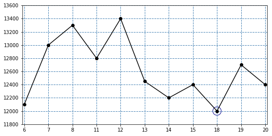

```python
f = plt.figure(figsize=(9,4.5))
ax = f.add_subplot(1,1,1)
ax.grid(c='steelblue', ls='--', lw=1)

days = ['6','7','8','11','12','13','14','15','18','19','20']
prices = [12100,13000,13300,12800,13400,12450,12200,12400,12000,12700,12400]

plt.xlim(-0.08,10.08)
plt.xticks(numpy.arange(0, 11, step=1))
plt.ylim(11800,13600)
plt.yticks(numpy.arange(11800, 13800, step=200))
ax.set_xticklabels(days)

ax.plot(numpy.arange(0, 11, step=1), prices,'-o', c='black')
ax.scatter(8, prices[8], s=300, facecolor='none', color='darkblue');
```

```python
answer_dictionary[2]=str(12000)
```

[figure not shown]

### Задание 3 / Task 3

На клетчатой бумаге с размером клетки 1х1 изображён равносторонний треугольник.

Найдите радиус описанной около него окружности.

An equilateral triangle is shown on graph paper with a cell size of 1x1.

Find the radius of the circle circumscribed about it.

Радиус описанной окружности равен ${\displaystyle R={\frac {2 * h}{3} = \frac {2 * 9}{3}} = 6}$

The radius of the circle circumscribing the three vertices is ${\displaystyle R={\frac {2 * h}{3} = \frac {2 * 9}{3}} = 6}$

### Ответ / Answer: 6

```python
answer_dictionary[3]=str(int(2*9/3))
```

[figure not shown]

### Задание 4 / Task 4

Перед началом матча по футболу судья бросает монету, чтобы определиться, какая из команд будет первая владеть мячом.

Команда "Белые" по очереди играет с командами "Красные", "Синие" и "Зеленые".

Найдите вероятность того, что ровно в одном матче право владеть мечом получит команда "Белые".

Before the start of the football match, the referee throws a coin to determine which team will be the first to own the ball.

The team "White" takes turns playing with the teams "Red", "Blue" and "Greens".

Find the probability that exactly in one match the right to own a sword will be given to the team "White".

| *white* / *red* | *white* / *blue* | *white* / *green* |
| --- | --- | --- |
| 0 | 0 | 0 |
| 1 | 0 | 0 |
| 0 | 1 | 0 |
| 1 | 1 | 0 |
| 0 | 0 | 1 |
| 1 | 0 | 1 |
| 0 | 1 | 1 |
| 1 | 1 | 1 |

В таблице $1$ означает, что право владеть мячом получает команда "Белые", $0$ - команда их соперника.

В трех случаях из восьми ровно в одном матче право владеть мечом получит команда "Белые.

In the table, $1$ means that the right to own a ball gets the command "White", $0$ - the command of their opponent.

In three cases out of eight exactly in one match the right to own a ball will receive the command "White".

### Ответ / Answer: 0,375

```python
answer_dictionary[4]=str(3/8)
```

[figure not shown]

### Задание 5 / Task 5

Найдите корень уравнения:

Find the root of the equation:

$\sqrt{x + 9} = 5$

$\sqrt{x + 9} = 5$

$x + 9 = 25$

$x = 16$

### Ответ / Answer: 16

```python
answer_dictionary[5]=str(5 ** 2 - 9)
```

[figure not shown]

### Задание 6 / Task 6

Диагонали трапеции ABCD с основаниями AB и CD пересекаются в точке M.

Найдите MC, если AB = 11, DC = 33, AC = 28.

The diagonals of the trapezoid ABCD with the bases AB and CD intersect at the point M.

Find MC if AB = 11, DC = 33, AC = 28.

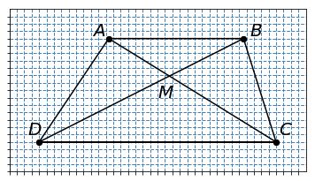

```python
f = plt.figure(figsize=(6,6))
ax = f.add_subplot(1, 1, 1, aspect=1)
ax.grid(c='steelblue', ls='--', lw=1)

ax.plot([-3.3,-8,8,5.8,-3.3,8,-8,5.8],
        [-1,-8,-8,-1,-1,-8,-8,-1],
        '-o', c='black')

v = numpy.array([[-8.8,8.2,-4.4,6.2,0],
                 [-7.5,-7.5,-0.8,-0.8,-5],
                 [r'$D$',r'$C$',r'$A$',r'$B$',r'$M$']])

for i in range(5):
    plt.text(float(v[0][i]),float(v[1][i]),v[2][i],fontsize=20)

plt.xlim(-10,10)
plt.ylim(-10,1)
plt.xticks(numpy.arange(-10, 10, step=0.5), visible=False)
plt.yticks(numpy.arange(-10, 1, step=0.5), visible=False);
```

$AB \ \| \ CD \implies \triangle MAB \sim \triangle MDC \implies DC : AB = MC : MA = 33 : 11 = 3 \implies MC = 3 * MA \ (1)$

$AC = MA + MC = 28 \implies MC = 28 - MA \implies 28 - MA = 3 * MA \implies MA = 7 \implies MC = 21$

### Ответ / Answer: 21

```python
answer_dictionary[6]=str(int(3 * 28 / 4))
```

[figure not shown]

### Задание 7 / Task 7

На рисунке изображен график функции y = f(x).

Прямая, проходящая через точку (-6;-1), касается этого графика в точке с абсциссой 6.

Найдите $f'(6)$.

The figure shows the graph of the function y = f (x).

A straight line passing through the point (-6; -1) touches this graph at the point with the abscissa 6.

Find $f '(6)$.

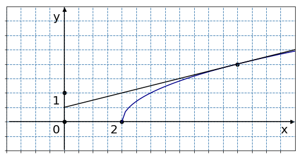

```python
f = plt.figure(figsize=(9,4.5))
ax = f.add_subplot(1, 1, 1, aspect=1)

ax.grid(c='steelblue', ls='--', lw=1)
plt.xlim(-2,8)
plt.ylim(-1,4)
plt.xticks(numpy.arange(-2, 8, step=0.5), visible=False)
plt.yticks(numpy.arange(-1, 4, step=0.5), visible=False)
ax.axhline(0, 0.01, 0.99, c='black')
ax.axvline(0, 0.01, 0.99, c='black')

v = numpy.array([[0,0], [0,1], [2,0], [0,3.9], [7.9,0], [6,2]])
m = ['o','o','o','^','>','o']
l = ['0','1','2','y','x']

for i in range(6):
    ax.scatter(v[i, 0], v[i, 1], marker=m[i], c='black')

for i in range(5):
    ax.text(v[i, 0]-0.4, v[i, 1]-0.4, l[i], fontsize=20)

x = numpy.linspace(2,8)
y = numpy.sqrt(x - 2)
ax.plot(x, y, c='darkblue')
ax.plot([0,8],[0.5,2.5], c='black');
```

Уравнение касательной, проходящей через точки (2,1) и (6,2):

The equation of the tangent line passing through the points (2,1) and (6,2):

$\large{\frac{x-2}{6-2} = \frac{y-1}{2-1}}$ $\iff y = 0.25 * x + 0.5$

Коэффициент 0.25 в уравнении прямой является тангенсом угла наклона касательной, проведенной к графику функции в определенной точке, и равен производной функции в этой точке:

The coefficient 0.25 in the line equation is the tangent of the slope angle for the tangent line drawn to the function graph at a certain point and is equal to the derivative value of the function at this point:

$f′(6) = 0.25$

### Ответ / Answer: 0.25

```python
answer_dictionary[7]=str(0.25)
```

[figure not shown]

### Задание 8 / Task 8

Цилиндр вписан в прямоугольный параллелепипед. Радиус основания цилиндра равен 2. Объем параллелепипеда равен 80.

Найдите высоту цилиндра.

The cylinder is inscribed in a rectangular parallelepiped. The radius of the base in this cylinder is 2. The volume of the parallelepiped is 80.

Find the height of the cylinder.

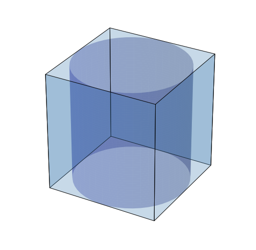

```python
f = plt.figure(figsize=(9,9))
ax = f.add_subplot(111, projection='3d')

def create_cylinder(center_x,center_y,radius,height):
    z = numpy.linspace(0, height, 50)
    theta = numpy.linspace(0, 2*numpy.pi, 50)
    theta_grid, z_grid = numpy.meshgrid(theta, z)
    x_grid = radius * numpy.cos(theta_grid) + center_x
    y_grid = radius * numpy.sin(theta_grid) + center_y
    return x_grid,y_grid,z_grid

Xc,Yc,Zc = create_cylinder(2.5,2.5,2.5,5)
ax.plot_surface(Xc, Yc, Zc, alpha=0.3, color='darkblue')

v = numpy.array([[0,0,0], [0,5,0], [5,0,0], [5,5,0],
                 [0,0,5], [0,5,5], [5,0,5], [5,5,5]])

verts = [ [v[0],v[4],v[5],v[1]],
          [v[0],v[4],v[6],v[2]],
          [v[3],v[7],v[6],v[2]],
          [v[3],v[7],v[5],v[1]],]

lines = Poly3DCollection(verts, lw=1, alpha=0.3,
                         edgecolors='black', facecolor='none')
lines.set_facecolor('steelblue')
ax.add_collection3d(lines)
plt.axis('off');
```

$V_p = S_p * h_p = a_p^2 * h_p \implies h_p = \large{\frac {V_p}{a_p^2}}$

$h_c = h_p$

$a_p = 2 * r_c \implies h_c = \large{\frac {V_p}{4 * r_c^2}}$

$h_c = 80 / 16 = 5$

### Ответ / Answer: 5

```python
answer_dictionary[8]=str(int(80/(4*4)))
```

[figure not shown]

### Задание 9 / Task 9

Найдите значение выражения

Find the value of the expression

$\large{\frac{\sqrt[40]{5} * \sqrt[24]{5}}{\sqrt[15]{5}}}$

$\large{\frac{\sqrt[40]{5} * \sqrt[24]{5}}{\sqrt[15]{5}} = 5^{\frac{1}{40} + \frac{1}{24} - \frac{1}{15}} = 5^{\frac{3 + 5 - 8}{120}} = 5^0 = 1}$

### Ответ / Answer: 1

```python
answer_dictionary[9]=str(int(math.pow(5,1/40)*math.pow(5,1/24)/math.pow(5,1/15)))
```

[figure not shown]

### Задание 10 / Task 10

Масса радиоактивного вещества уменьшается по закону $m(t) = m_0 * 2^{-\large{\frac{t}{T}}}$.

В лаборатории получили вещество, содержащее в начальный момент времени $m_0 = 280$ мкг изотопа железа-59, период полураспада которого $T = 45$ суток.

В течение скольких суток содержание изотопа железа-59 в веществе будет превосходить 17,5 мкг?

The mass of the radioactive substance decreases according to the law $m(t) = m_0 * 2^{-\large{\frac{t}{T}}}$.

In the laboratory, a substance was obtained containing, at the initial time, $m_0 = 280$ μg of the iron isotope-59, whose half-life is $T = 45$ days.

For how many days the content of the iron-59 isotope in the substance will exceed 17.5 μg?

$\large{17.5 = 280 * 2^{-\frac{t}{45}}}$

$\large{2^{-4} = (2^t)^{-\frac{1}{45}}}$

$\large{(2^{180})^{-\frac{1}{45}} = (2^t)^{-\frac{1}{45}}}$

$\large{2^{180} = 2^t}$

$t = 180$

### Ответ / Answer: 180

```python
answer_dictionary[10]=str(180)
```

[figure not shown]

### Задание 11 / Task 11

Имеются два сосуда, содержащие 42 кг и 6 кг раствора кислоты различной концентрации.

Если эти растворы смешать, то получится раствор, содержащий 40% кислоты.

Если смешать равные массы этих растворов, то получится раствор, содержащий 50% кислоты.

Сколько килограммов кислоты содержится в первом растворе?

There are two vessels containing 42 kg and 6 kg of acid solution of different concentrations.

If these solutions are mixed, a solution containing 40% acid will be obtained.

If you mix equal masses of these solutions, you will get a solution containing 50% acid.

How many kilograms of acid is contained in the first solution?

Пусть $x$ - концентрация первого раствора (в долях), $y$ - второго.

Тогда в первом сосуде содержится $42 * x$ кислоты, а во втором - $6 * y$.

При смешивании жидкостей в сосудах получается $(42 + 6) * 0.4 = 19.2$ кислоты.

$42 * x + 6 * y = 19.2$

При смешивании равного количества указанных растворов (например, по одному кг) количество кислоты равно:

$1 * x + 1 * y = (1 + 1) * 0.5 \implies y = 1 - x \implies 42 * x + 6 * (1 - x) = 19.2$

$x = \large{\frac{11}{30}}$

$42 * 11 / 30 = 15.4$

### Ответ / Answer: 15.4

```python
answer_dictionary[11]=str(15.4)
```

[figure not shown]

### Задание 12 / Task 12

Найдите наименьшее значение функции

Find the least value of the function

$e^{2 * x} - 14 * e^x + 5$

на отрезке $[-1;2]$.

on the interval $[-1;2]$.

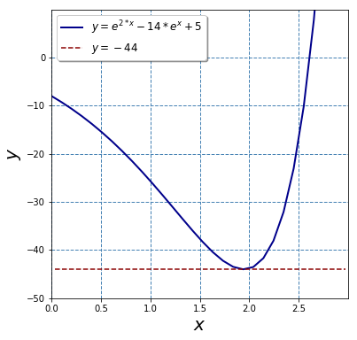

```python
f = plt.figure(figsize=(6,6))
ax = f.add_subplot(1, 1, 1)
ax.grid(c='steelblue', ls='--', lw=1)

def f(x):
    return math.e ** (2 * x) - 14 * math.e ** x + 5

x = numpy.linspace(0,5)
y = [f(el) for el in x]
ax.plot(x, y, c='darkblue', lw=2,
        label=r'$y = e^{2 * x} - 14 * e^x + 5$')

ax.axhline(-44, 0.01, 0.99, c='darkred',
           ls='--',label=r'$y=-44$')

plt.xlim(0,3)
plt.ylim(-50,10)
plt.xticks(numpy.arange(0,3, step=0.5))
plt.yticks(numpy.arange(-50,10, step=10))

plt.xlabel(r'$x$', fontsize=20)
plt.ylabel(r'$y$', fontsize=20)
plt.legend(fontsize=12, shadow=True, loc=2);
```

```python
x = Symbol('x')
y = E**(2*x) - 14*E**x + 5
```

```python
# производная | the first derivative
diff(y,x)
```

$$2 e^{2 x} - 14 e^{x}$$

```python
# производная равна нулю: ∣ the first derivative is 0
solve(diff(y,x),x)
```

$$\left [ \log{\left (7 \right )}\right ]$$

```python
# вторая производная / the second derivative
diff(diff(y,x),x)
```

$$4 e^{2 x} - 14 e^{x}$$

```python
# y''(log(7)) > 0 => min
diff(diff(y,x),x).subs({x:log(7)})
```

$$98$$

```python
# y(log(7))
y.subs({x:log(7)})
```

$$-44$$

```python
# y(-1)
N(y.subs({x:-1}))
```

$$-0.0149768931635798$$

```python
# y(-1)
N(y.subs({x:2}))
```

$$-43.8486353518849$$

### Ответ / Answer: -44

```python
answer_dictionary[12]=str(-44)
```

## Часть 2 Part 2

[figure not shown]

### Задание 13 / Task 13

a) Найдите корень уравнения:

a) Find the root of the equation:

$\large{\frac{\log_{5}{(-2 * cos \ x)}}{ \sqrt{5 * tg \ x}}}$ $= 0$.

б) Найдите все корни этого уравнения, принадлежащие промежутку

b) Find all the roots of this equation that belong to the interval

$\bigg[\large{\frac{\pi}{2}}$; $2 * \pi \bigg]$.

a)

$\large{\frac{\log_{5}{(-2 * cos \ x)}}{ \sqrt{5 * tg \ x}}}$ $= 0$.

1) Область допустимых значений / Admissible values:

$tg \ x > 0 \iff \pi * n < x < \pi * n + \large{\frac{\pi}{2}}$$, n \in \mathbb{N}$

2)

$\log_{5}{(-2 * cos \ x)} = 0$

$\log_{5}{(-2 * cos \ x)} = \log_{5}{1}$

$-2 * cos \ x = 1$

$cos \ x = -\large{\frac{1}{2}}$

$x = -\large{\frac{2*\pi}{3}}$$ + 2 * \pi * k, k \in \mathbb{N}$

b) $\large{\frac{4 * \pi}{3} \in \bigg[\frac{\pi}{2}}$$; 2 * \pi \bigg]$

### Ответ / Answer: a) $-\large{\frac{2*\pi}{3}}$$ + 2 * \pi * k, k \in \mathbb{N}$; б) $\large{\frac{4 * \pi}{3}}$.

```python
# check the decision method
x = Symbol('x')
g = log(-2 * cos(x), 5) / sqrt(5 * tan(x))
```

```python
g
```

$$\frac{\sqrt{5} \log{\left (- 2 \cos{\left (x \right )} \right )}}{5 \log{\left (5 \right )} \sqrt{\tan{\left (x \right )}}}$$

```python
solve(g,x)
```

$$\left [ \frac{2 \pi}{3}, \quad \frac{4 \pi}{3}\right ]$$

```python
solve(tan(x)>0)
```

$$0 < x \wedge x < \frac{\pi}{2}$$

```python
answer_dictionary[13]='a)−2π/3+2πk,k∈ℕ; б)4π/3'
```

[figure not shown]

### Задание 14 / Task 14

Диаметр окружности основания цилиндра равен 26, образующая цилиндра равна 21.

Плоскость пересекает его основания по хордам длины 24 и 10.

Расстояние между этими хордами равно $\sqrt{730}$.

а) Постройте прямую пересечения этой плоскости с плоскостью, проходящей через диаметры оснований, перпендикулярные этим хордам.

б) Найдите угол между этой плоскостью и плоскостью основания цилиндра.

The diameter of the cylinder bases is 26, the height of the cylinder is 21.

The plane crosses cylinder bases along the chords of lengths 24 and 10.

The distance between these chords is $\sqrt{730}$.

a) Construct the line of intersection of this plane with the plane passing through the diameters of the bases, perpendicular to these chords.

b) Find the angle between this plane and the plane of the cylinder base.

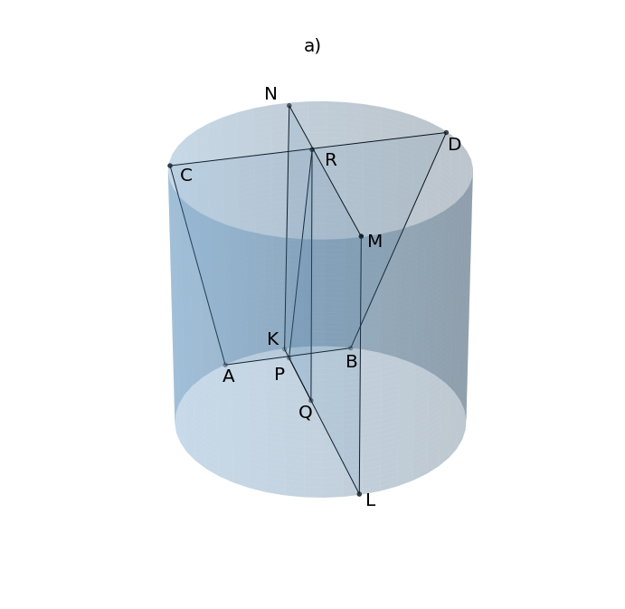

```python
f = plt.figure(figsize=(12,12))
ax = f.add_subplot(111, projection='3d')

Xc,Yc,Zc = create_cylinder(0,0,1,4)
ax.plot_surface(Xc, Yc, Zc, alpha=0.3, color='steelblue')

letter_xyz = numpy.array([[-0.85,0.1,0],[-0.2,0.7,0],[-0.7,-0.62,4],[0.6,0.65,4],
                          [-0.85,0.7,0],[0.8,-0.8,0],[0.8,-0.8,4],[-0.85,0.7,4],
                          [-0.55,0.3,0],[-0.15,-0.05,0],[0,0.05,4]])
letter_symbols = numpy.array(['A','B','C','D',
                              'K','L','M','N',
                              'P','Q','R'])

for i in range(len(letter_xyz)):
    ax.text(letter_xyz[i][0], letter_xyz[i][1], letter_xyz[i][2],
            letter_symbols[i], color='black', fontsize=20)

v = numpy.array([[0.7,-0.7,0], [-0.7,0.7,0], [0.7,-0.7,4], [-0.65,0.7,4],
                 [-0.3,0.95,0], [-0.95,0.3,0], [-0.87,-0.47,4], [0.47,0.87,4],
                 [-0.61,0.61,0], [-0.18,0.2,4], [-0.18,0.18,0]])
ax.scatter3D(v[:, 0], v[:, 1], v[:, 2], color='black')

verts = [ [v[0],v[2],v[3],v[1]], [v[4],v[5],v[6],v[7]], [v[8],v[9],v[10]] ]

lines = Poly3DCollection(verts, lw=1, alpha=0.1,
                         edgecolors='black', facecolor='none')
lines.set_facecolor('steelblue')
ax.add_collection3d(lines)

plt.title('a)', fontsize=20);
plt.axis('off');
```

б)

1)

По построению $NM = KL = 26$ - диаметры оснований; $AB \bot KL, CD \bot NM$.

Плоскости $ABC$ и $NMK$ пересекают каждое из оснований цилиндра по перпендикулярным прямым $\implies ABC \bot NMK$.

$ABC \cap NMK = PR \implies PR \bot AB, PR \bot CD, PR \bot KL, PR \bot MN$.

Опустим перпендикуляр PQ на плоскость основания ABL. По теореме о трех перпендикулярах $PQ \bot AB \implies$ необходимо найти $\angle RPQ$.

By drawing, $NM = KL = 26$ are the diameters of the bases; $AB \bot KL, CD \bot NM$.

The planes $ABC$ and $NMK$ intersect each of the cylinder bases along the perpendicular lines $\implies ABC \bot NMK$.

$ABC \cap NMK = PR \implies PR \bot AB, PR \bot CD, PR \bot KL, PR \bot MN$.

Let's lower the perpendicular PQ to the plane of the base ABL. By the theorem on three perpendiculars $PQ \bot AB \implies$ it is necessary to find $\angle RPQ$.

2)

$PQ \bot KM \implies \sin (\angle QPR) = \large{\frac{RQ}{PQ}}$ $\implies \sin (\angle QPR) =$ $\large{\frac{21}{\sqrt{730}}}$

$\implies \cos (\angle QPR) = 1 - \sin^2 (\angle QPR) = \large{\frac{17}{\sqrt{730}}}$

$\implies \tan (\angle QPR) =$ $\large{\frac{\sin (\angle QPR)}{\cos (\angle QPR)}} = \large{\frac{21}{17}}$

### Ответ / Answer: $б) \arctan{\large{\frac{21}{17}}}$

```python
answer_dictionary[14]=str('б) arctg(21/17)')
```

[figure not shown]

### Задание 15 / Task 15

Решите неравенство:

Solve the inequality:

$\log_{2 - x}{(x + 2)} * \log_{x + 3}{(3 - x)} \leq 0$

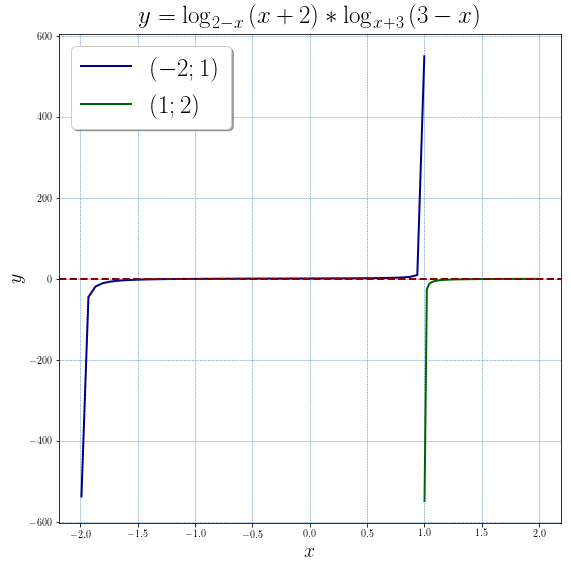

```python
matplotlib.rcParams['text.usetex'] = True
matplotlib.rcParams['text.latex.unicode'] = True
plt.figure(figsize=(9,9))

plt.grid(c='steelblue', ls='--', lw=0.5)
plt.xlabel(r'$x$', fontsize=20)
plt.ylabel(r'$y$', fontsize=20)

a = [-1.99,1.001]
b = [0.999,1.99]
colors = ['darkblue','darkgreen','royalblue']
labels = [r'$(-2;1)$',r'$(1;2)$']
x = numpy.array([numpy.linspace(i,j) for i,j in zip(a,b)])
y = numpy.array([[log(el+2,2-el)*log(3-el,el+3) for el in x[i]] for i in range(2)])

for i in range(2):
    plt.plot(x[i], y[i], c=colors[i], lw=2, label=labels[i])

plt.axhline(0, c='darkred', ls='--', lw=2)

plt.legend(fontsize=25, shadow=True, loc=2)
plt.title(r'$y = \log_{2 - x}{(x + 2)} * \log_{x + 3}{(3 - x)}$', fontsize=25);
```

1) Область допустимых значений: / The range of admissible values:

$\begin{cases} x + 2 > 0 \\ 3 - x > 0 \\ 2 - x > 0 \\ 2 - x \neq 1 \\ x + 3 > 0 \\ x + 3 \neq 1 \end{cases} \iff \begin{cases} x > -2 \\ x < 3 \\ x < 2 \\ x \neq 1 \\ x > -3 \\ x \neq -2 \end{cases} \iff -2 < x < 1 \lor 1 < x < 2$

2) Преобразования неравенства с использованием метода декомпозиции: / Inequality transformations using the decomposition method:

$\log_{f(x)} {g(x)} * \log_{v(x)} {u(x)} \leq 0 \iff (f(x) - 1) * (g(x) - 1) * (v(x) - 1) * (u(x) - 1) \leq 0$

$(2 - x - 1) * (x + 2 - 1) * (x + 3 - 1) * (3 - x - 1) \leq 0 \iff (x - 1) * (x - 2) * (x + 1) * (x + 2)\leq 0 \iff -2 \leq x \leq -1 \lor 1 \leq x \leq 2$

3) $1) \land 2)$

$-2 < x \leq -1 \lor 1 < x < 2$

### Ответ / Answer: $(-2;-1] \cup (1;2)$

```python
answer_dictionary[15]='(-2;-1]∪(1;2)'
```

[figure not shown]

### Задание 16 / Task 16

Дана окружность радиуса 2 с центром O. Хорда AB пересекает радиус OC в точке D, причём $\angle CDA = 120^o$. Известно, что $OD = \sqrt{3}$.

а) Докажите, что расстояние от O до хорды AB равно 1.5.

б) Найдите радиус окружности, вписанной в угол ADC и касающейся дуги AC.

A circle of radius 2 with center O is given. The chord AB intersects the radius OC at point D, and $\angle CDA = 120^o$. It is known that $OD = \sqrt{3}$.

a) Prove that the distance from O to the chord AB is 1.5.

b) Find the radius of the circle inscribed in the angle ADC and touching the arc AC.

*Внутреннее касание окружностей / Internal tangency of circles*

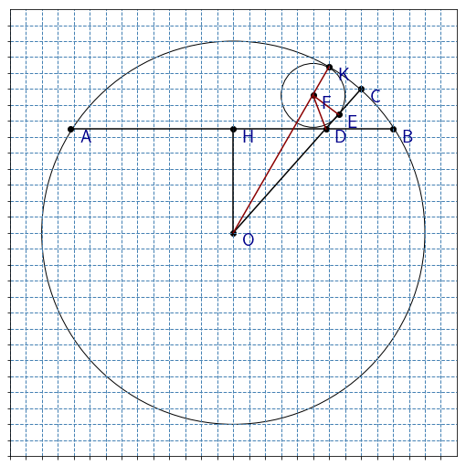

```python
f = plt.figure(figsize=(9,9))
ax = f.add_subplot(1, 1, 1, aspect=1)
ax.grid(c='steelblue', ls='--', lw=1)

plt.xlim(-7,7)
plt.ylim(-7,7)
plt.xticks(numpy.arange(-7, 7, step=0.5), visible=False)
plt.yticks(numpy.arange(-7, 7, step=0.5), visible=False)

ax.axhline(3.24, 0.14, 0.85, c='black')
ax.axvline(0, 0.5, 0.73, c='black')
ax.plot([0,4],[0,4.5], c='black')
ax.plot([0,3],[0,5.2], c='darkred')
ax.plot([2.5,2.9],[4.3,3.25], c='darkred')
ax.plot([2.5,3.3],[4.3,3.7], c='darkred')

letter_xy = numpy.array([[0,0],[-5.1,3.25],[5,3.25],[4,4.5],
                         [2.9,3.25],[3.3,3.7],[2.5, 4.3],[0,3.25],[3,5.2]])
letter_symbols = numpy.array(['O','A','B','C','D','E','F','H','K'])

for i in range(len(letter_xy)):
    ax.text(letter_xy[i][0]+0.3, letter_xy[i][1]-0.4,
            letter_symbols[i], color='darkblue', fontsize=20)

ax.scatter(letter_xy[:, 0], letter_xy[:, 1], color='black')

circle = pat.Circle((0, 0), 6, lw=1,
                    edgecolor='black', facecolor='none')
circle2 = pat.Circle((2.5, 4.3), 1, lw=1,
                     edgecolor='black', facecolor='none')
ax.add_artist(circle)
ax.add_artist(circle2);
```

Построим перпендикуляр к хорде AB и вписанную в угол CDA окружность с центром в точке F.

Let's construct a perpendicular to the chord AB and a circle inscribed in the angle CDA with center at the point F.

$OH: OH \bot AB; \; OK: F \in OK, OK = OC, FK = FE = r, FE \bot CO$.

а)

Углы HDO и CDA - смежные, треугольник HDO - прямоугольный.

The angles HDO and CDA are contiguous, the triangle HDO is rectangular.

$\angle HDO = 180^o - \angle CDA = 180^o - 120^o = 60^o$

$OH = OD * sin \angle HDO = \sqrt{3} * \frac{\sqrt{3}}{2} = 1.5$

б)

Центр вписанной в угол окружности равноудален от его сторон и расположен на биссектрисе этого угла.

The center of the inscribed circle is equidistant from the angle sides and is located on the bisector of this angle.

$\triangle DFE: FE \bot ED; \; \angle FDE = \angle CDA / 2 = 120^o / 2 = 60^o; \; DE = FE * ctg \angle FDE = \frac{r * \sqrt{3}}{3}$

$\triangle OFE: OF = OK - FK = 2 - r; \; OE = OD + DE = \sqrt{3} + \frac{r * \sqrt{3}}{3}; \; FE = r$

По теореме Пифагора:

By the Pythagorean theorem:

$OF^2 = OE^2 + FE^2 \iff (2 - r)^2 = (\sqrt{3} + \frac{r * \sqrt{3}}{3})^2 + r^2$

$4 - 4 * r + r^2 = 3 + 2 * r + r^2 / 3 + r^2 \iff r^2 + 18 * r - 3 = 0$

$D = 18^2 - 4 * 1 * (-3) = 336 \implies r = \frac{-18 + 4 * \sqrt{21}}{2} = 2 * \sqrt{21} - 9$

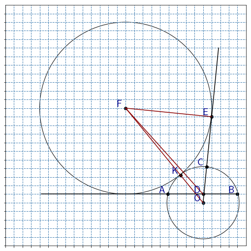

```python
f = plt.figure(figsize=(9,9))
ax = f.add_subplot(1, 1, 1, aspect=1)
ax.grid(c='steelblue', ls='--', lw=1)

plt.xlim(-7,7)
plt.ylim(-7,7)
plt.xticks(numpy.arange(-7, 7, step=0.5), visible=False)
plt.yticks(numpy.arange(-7, 7, step=0.5), visible=False)

ax.axhline(-4, 0.15, 0.97, c='black')
ax.plot([4.5,5.4],[-4.5,4.5], c='black')
ax.plot([0,4.5],[1,-4.5], c='darkred')
ax.plot([0,5],[1,0.5], c='darkred')
ax.plot([0,4.5],[1,-4], c='darkred')

letter_xy = numpy.array([[4.5,-4.5],[2.45,-4],[6.5,-4],[4.7,-2.4],
                         [4.5,-4],[5,0.5],[0, 1],[3.2,-2.9]])
letter_symbols = numpy.array(['O','A','B','C','D','E','F','K'])

for i in range(len(letter_xy)):
    ax.text(letter_xy[i][0]-0.5, letter_xy[i][1]+0.1,
            letter_symbols[i], color='darkblue', fontsize=20)

ax.scatter(letter_xy[:, 0], letter_xy[:, 1], color='black')

circle = pat.Circle((0, 1), 5, lw=1,
                    edgecolor='black', facecolor='none')
circle2 = pat.Circle((4.5, -4.5), 2.1, lw=1,
                     edgecolor='black', facecolor='none')
ax.add_artist(circle)
ax.add_artist(circle2);
```

Рассуждения аналогичны, за исключением того, что отрезок OF будет равен не разности, а сумме радиусов окружностей.

The reasoning is similar, except that the segment OF will be equal to the sum of the radii of the circles, not the difference.

$OF^2 = OE^2 + FE^2 \iff (2 + r)^2 = (\sqrt{3} + \frac{r * \sqrt{3}}{3})^2 + r^2$

$4 + 4 * r + r^2 = 3 + 2 * r + r^2 / 3 + r^2 \iff r^2 - 6 * r - 3 = 0$

$D = 6^2 - 4 * 1 * (-3) = 48 \implies r = \frac{6 + 4 * \sqrt{3}}{2} = 2 * \sqrt{3} + 3$

### Ответ / Answer: б) $2 \sqrt{21} - 9 \lor 2 \sqrt{3} + 3$

```python
answer_dictionary[16]='б)2√21−9 ∨ 2√3+3'
```

[figure not shown]

### Задание 17 / Task 17

У фермера есть два поля, каждое площадью 10 гектаров.

На каждом поле можно выращивать картофель и свеклу, поля можно делить между этими культурами в любой пропорции.

Урожайность картофеля на первом поле составляет 300 ц/га, а на втором - 200 ц/га.

Урожайность свеклы на первом поле составляет 200 ц/га, а на втором - 300 ц/га.

Фермер может продавать картофель по цене 3000 руб. за центнер, а свеклу - по цене 4000 руб. за центнер.

Какой наибольший доход может получить фермер?

The farmer has two fields, each with an area of 10 hectares.

Each field can grow potatoes and beet, the fields can be divided between these crops in any proportion.

The yield of potatoes in the first field is 300 c/ha, and on the second - 200 c/ha.

The yield of beet in the first field is 200 c/ha, and on the second - 300 c/ha.

A farmer can sell potatoes at a price of 3000 rubles for a centner, and beetroot - at a price of 4000 rubles for a centner.

What is the largest income that a farmer can get?

1) На первом поле урожайность картофеля в 300 / 200 = 1.5 раза выше, а цена в 3000/4000 = 0.75 раза меньше. Произведение этих показателей больше единицы ⟹ Снижение дохода из-за более низкой цены картофеля компенсируется его высокой урожайностью. ⟹ Оптимальный доход можно получить, выращивая только картофель.

$10 * 300 * 3000 = 9000000$

2) На втором поле урожайность свеклы выше, ее цена больше. ⟹ Единственный способ получить оптимальный доход - выращивать только свеклу.

$10 * 300 * 4000 = 12000000$

3) Итого:

$9000000 + 12000000 = 21000000$

### Ответ / Answer: 21 млн.руб.

```python
answer_dictionary[17]='21 000 000'
```

[figure not shown]

### Задание 18 / Task 18

Найдите все значения параметра a, при каждом из которых модуль разности корней уравнения

$x^2 - 6 * x + 12 + a^2 - 4 * a = 0$

принимает наибольшие значения.

Find all the values of the parameter a, for each of which the modulus of the root difference of the equation

$x^2 - 6 * x + 12 + a^2 - 4 * a = 0$

takes the greatest values.

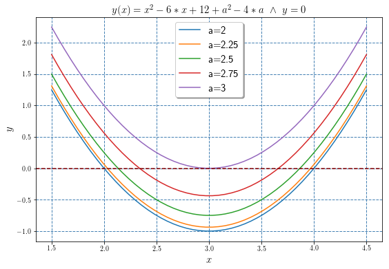

```python
def F(x,a): return x ** 2 - 6 * x + 12 + a **2 - 4 * a
X = numpy.linspace(1.5, 4.5)

plt.figure(figsize=(9,6))
for a in [2, 2.25, 2.5, 2.75, 3]:
    plt.plot(X, [F(x,a) for x in X], label='a='+str(a))

plt.axhline(0, c='darkred', ls='--')
plt.legend(shadow=True, loc=9, fontsize=15)
plt.xlabel(r'$x$', fontsize=15)
plt.ylabel(r'$y$', fontsize=15)
plt.title(r'$y(x) = x^2 - 6 * x + 12 + a^2 - 4 * a \ \land \ y = 0$', fontsize=15)
plt.grid(c='steelblue', ls='--', lw=1);
```

$x^2 - 6 * x + 12 + a^2 - 4 * a = 0$

$x_1 - x_2 = \large{\frac{6 + \sqrt{6^2 - 4 * (12 + a^2 - 4 * a)}}{2} - \frac{6 - \sqrt{6^2 - 4 * (12 + a^2 - 4 * a)}}{2}}$

$x_1 - x_2 = \sqrt{6^2 - 4 * (12 + a^2 - 4 * a)}$

$x_1 - x_2 = 2 * \sqrt{- a^2 + 4 * a - 3}$

$x_1 - x_2 - max \iff f(a) = - a^2 + 4 * a - 3 - max$

$f'(a) = -2 * a + 4; \ f'(2) = 0; \ f''(a) = -2 \implies f(a) - max \iff a = 2$

### Ответ / Answer: 2

```python
# check the decision method
x = Symbol('x')
a = Symbol('a')
```

```python
m = 2 * sqrt(-a ** 2 + 4 * a - 3)
```

```python
diff(m,a)
```

$$\frac{2 \left(- a + 2\right)}{\sqrt{- a^{2} + 4 a - 3}}$$

```python
solve(diff(m,a),a)
```

$$\left [ 2\right ]$$

```python
diff(diff(m,a),a)
```

$$\frac{2 \left(- a + 2\right) \left(a - 2\right)}{\left(- a^{2} + 4 a - 3\right)^{\frac{3}{2}}} - \frac{2}{\sqrt{- a^{2} + 4 a - 3}}$$

```python
diff(diff(m,a),a).subs({a:2})
```

$$-2$$

```python
n = x ** 2 - 6 * x + 12 + a ** 2 - 4 * a
```

```python
n.subs({a:2})
```

$$x^{2} - 6 x + 8$$

```python
# a=2
solve(x ** 2 - 6 * x + 12 + 2 ** 2 - 4 * 2, x)
```

$$\left [ 2, \quad 4\right ]$$

```python
answer_dictionary[18]='a=2'
```

[figure not shown]

### Задание 19 / Task 19

а) Приведите пример такого натурального числа n, что числа $n^2$ и $(n + 24)^2$ дают одинаковый остаток при делении на 100.

б) Сколько существует трехзначных чисел $n$ с указанным в пункте а) свойством?

в) Сколько существует двузначных чисел $m$, для каждого из которых существует ровно 36 трехзначных чисел $n$, таких что $n^2$ и $(n + m)^2$ дают одинаковый остаток при делении на 100.

a) Give an example of a natural number n for which the numbers $ n ^ 2 $ and $ (n + 24) ^ 2 $ give the same remainder of division by 100.

b) How many three-digit numbers $n$ exist with the property indicated in a)?

c) How many double-digit numbers $m$ exist, for each of which there are exactly 36 three-digit numbers $n$ such that $n^2$ and $(n + m)^2$ give the same remainder of division by 100.

а)

$n^2$ и $(n + 24)^2 = n^2 + 48 * n + 576$ делятся на 100 с одинаковым остатком, если $48 * n + 576$ делится на 100 без остатка.

$100 = 4 * 25; 48 * n + 576 = 4 * 12 * (n + 12) \implies (n + 12)$ должно делиться на 25 без остатка.

Например, при $n = 13: 13^2 = 169 ; (13 + 24)^2 = 1369$. Остаток от деления на 100 равен 69.

б)

Определим, сколько трехзначных чисел делится на 25 без остатка:

$(999 - 99) / 25 = 36; (n + 12) \in \{100, 125, ..., 975\}$

Значит, трехзначных n, таких что n + 12 делится на 25 без остатка также будет 36:

$n \in \{113 \ (113 + 12 = 125), 138 \ (138 + 12 = 150), ..., 988 \ (988 + 12 = 1000)\}$

в)

$n^2$ и $(n + m)^2 = n^2 + 2 * n * m + m^2$ делятся на 100 с одинаковым остатком, если $2 * n * m + m^2$ делится на 100 без остатка.

$\large {\frac {2 * n * m + m^2}{100}}$$ \in \mathbb {N} \implies m - четное \implies m = 2 * k, 5 \leq k \leq 49$

$\large {\frac {2 * n * 2 * k + 2^2 * k^2}{100} = \frac {n * k + k^2}{25} = \frac {k * (n + k)}{25}} \in \mathbb{N}$.

I. $k$ кратно 25 $\implies n$ может быть любым трехзначным числом $\implies$ таких чисел больше 36.

II. $k$ кратно 5$ \implies n$ может быть любым трехзначным числом, кратным 5 $\implies$ таких чисел больше 36.

III. $k$ не кратно 5 и 25: для каждого из таких 36 чисел $k \in \{6,7,8,9,11,12,13,14,...,46,47,48,49\}$ найдется ровно 36 трезначных чисел так, чтобы $(n + k)$ делилось нацело на 25 по аналогии с п. б).

| $k$ | $n$ | $n + k$ |
| --- | --- | --- |
| $6$ | $\{119,144,...,994\}$ | $\{125,150,...,1000\}$ |
| ... | ... | ... |
| $9$ | $\{116,141,...,991\}$ | $\{125,150,...,1000\}$ |
| ... | ... | ... |
| $46$ | $\{104,129,...,979\}$ | $\{150,175,...,1025\}$ |
| ... | ... | ... |
| $49$ | $\{101,126,...,976\}$ | $\{150,175,...,1025\}$ |

36 числам $k$ соответствуют 36 чисел $m \in \{12,14,16,18,22,24,26,28,...,92,94,96,98\}$.

a)

$n^2$ and $(n + 24)^2 = n^2 + 48 * n + 576$ are divided by 100 with the same remainder if $48 * n + 576$ is divisible by 100 without a remainder.

$100 = 4 * 25; 48 * n + 576 = 4 * 12 * (n + 12) \implies (n + 12)$ must be divisible by 25 without a remainder.

For example, for $n = 13: 13^2 = 169; (13 + 24)^2 = 1369$. The remainder of division by 100 is 69.

b)

Let's find how many three-digit numbers are divided by 25 without a remainder:

$(999 - 99) / 25 = 36; (n + 12) \in \{100, 125, ..., 975 \}$

Therefore, the number of three-digit n, such as n + 12 is divisible by 25 without a remainder, will also be 36:

$n \in \{113 \ (113 + 12 = 125), 138 \ (138 + 12 = 150), ..., 988 \ (988 + 12 = 1000)\}$

c)

$n^2$ and $(n + m)^2 = n^2 + 2 * n * m + m^2$ are divisible by 100 with the same remainder if $2 * n * m + m^2$ is divisible by 100 without a remainder.

$\large {\frac {2 * n * m + m^2}{100}}$$ \in \mathbb {N} \implies m - even \implies m = 2 * k, 5 \leq k \leq 49$

$\large {\frac {2 * n * 2 * k + 2^2 * k^2}{100} = \frac {n * k + k^2}{25} = \frac {k * (n + k)}{25}} \in \mathbb{N}$.

I. $k$ is a multiple of 25 $\implies n$ can be any three-digit number $\implies$ numbers of n is greater than 36.

II. $k$ is a multiple of 5 $\implies n$ can be any three-digit number that is a multiple of 5 $\implies$ numbers of n is greater than 36.

III. $k$ is not a multiple of 5 and 25: for each of these 36 numbers $ k \in \{6,7,8,9,11,12,13,14, ..., 46,47,48,49 \}$ there are exactly 36 three-digit numbers so that $(n + k)$ is divisible by 25 without a remainder by analogy with b).

36 numbers $k$ correspond to 36 numbers $m \in \{12,14,16,18,22,24,26,28,...,92,94,96,98\}$.

### Ответ / Answer: а) 13; б) 36; в) 36

```python
answer_dictionary[19]='а)13; б)36; в)36'
```

## Ответы / Answers

| 1 | 2 | 3 | 4 | 5 | 6 | 7 | 8 | 9 | 10 | 11 | 12 |
| --- | --- | --- | --- | --- | --- | --- | --- | --- | --- | --- | --- |
| 70 | 12000 | 6 | 0.375 | 16 | 21 | 0.25 | 5 | 1 | 180 | 15.4 | -44 |

| 13 | 14 | 15 | 16 | 17 | 18 | 19 |
| --- | --- | --- | --- | --- | --- | --- |
| a) $-\large{\frac{2*\pi}{3}}$$ + 2 * \pi * k,$ $k \in \mathbb{N}$; б) $\large{\frac{4 * \pi}{3}}$ | $б) \arctan{\large{\frac{21}{17}}}$ | $(-2;-1] \cup (1;2)$ | б) $2 \sqrt{21} - 9 \; \lor$ $2 \sqrt{3} + 3$ | 21 000 000 | 2 | а) 13; б) 36; в) 36 |

```python
# answer_dictionary
```

[figure not shown]